# Becoming one with the data structure

Rather than exploring the content itself, this notebook focuses on understanding how the data is structured and organized.

As the final objective is to train a YOLO model to detect different human and vehicle types, and since YOLO requires a specific data structure, we will check whether the existing organization meets these requirements. If necessary, we will also do the adjustments needed to make it fully compatible with YOLO.To become one with the data structure, we establish a clear understanding of its composition:

- The directory structure and file paths
- The different versions available for each image
- The structure of the annotation JSON files
- Conversion of relevant labels into the YOLO instance segmentation format

## 1 Structure of the image and annotation directories

The Cityscapes dataset is structured as follows:

```
data/
    leftImg8bit/ # images from the left camera without labels
        train/
        val/
        test/
    gtFine/      # # Fine-grained annotations + additional format variants
        train/
        val/
        test/
```

Each split (train, val, test) contains subfolders for each city, where the corresponding images and annotations are stored. Since Cityscapes does not provide annotations for the test set and we will later use the data from Zürich as test set, we will ignore the test folders.

We start now by checking if all paths are valid and start building our `overview_df` by collecting the paths to the images inside the leftImg8bit folder. During this process, we also extract metadata such as the data split (train, val) and the city, as these attributes may be helpful for later stages of our analysis.

```python
from pathlib import Path
import json
from PIL import Image
import numpy as np
import matplotlib.pyplot as plt
from collections import Counter
import pandas as pd

# Define paths
datafolder = Path("..") / "data"
img_dir = datafolder / "leftImg8bit_trainvaltest" / "leftImg8bit"
ann_dir = datafolder / "gtFine_trainvaltest" / "gtFine"

print(f"Image directory found: {img_dir}")
print(f"Annotation directory found: {ann_dir}")
```

```
Image directory found: ..\data\leftImg8bit_trainvaltest\leftImg8bit
Annotation directory found: ..\data\gtFine_trainvaltest\gtFine
```

```python
# only include train and val set
splits = ['train', 'val']

def get_image_annotation_dirs(split, img_dir=img_dir, ann_dir=ann_dir):
    """get the paths from the given split and check if they exist"""
    img_path = img_dir / split
    ann_path = ann_dir / split

    print(f"Image directory for {split} found: {img_path.exists()}")
    print(f"Annotation directory for {split} found: {ann_path.exists()}")
    return img_path, ann_path



split_dirs = {split: get_image_annotation_dirs(split, img_dir=img_dir, ann_dir=ann_dir) for split in splits}
```

```
Image directory for train found: True
Annotation directory for train found: True
Image directory for val found: True
Annotation directory for val found: True
```

```python
# start building the overview_df

rows = []

for split in splits:
    img_path, ann_path = split_dirs[split]

    # find images in the folder "leftImg8bit"
    image_files = list(img_path.glob("*/*.png"))

    # iterate over all images and append the information to the rows
    for img_file in image_files:
        rows.append({
            "image_name": img_file.name.replace('_leftImg8bit.png', ''),
            "image_path": str(img_file),
            "split": split,
            "city": Path(img_file).parent.name
        })

# Create the overview DataFrame
df_overview = pd.DataFrame(rows)


df_overview
```

|  | image_name | image_path | split | city |
| --- | --- | --- | --- | --- |
| 0 | aachen_000000_000019 | ..\data\leftImg8bit_trainvaltest\leftImg8bit\t... | train | aachen |
| 1 | aachen_000001_000019 | ..\data\leftImg8bit_trainvaltest\leftImg8bit\t... | train | aachen |
| 2 | aachen_000002_000019 | ..\data\leftImg8bit_trainvaltest\leftImg8bit\t... | train | aachen |
| 3 | aachen_000003_000019 | ..\data\leftImg8bit_trainvaltest\leftImg8bit\t... | train | aachen |
| 4 | aachen_000004_000019 | ..\data\leftImg8bit_trainvaltest\leftImg8bit\t... | train | aachen |
| ... | ... | ... | ... | ... |
| 3470 | munster_000169_000019 | ..\data\leftImg8bit_trainvaltest\leftImg8bit\v... | val | munster |
| 3471 | munster_000170_000019 | ..\data\leftImg8bit_trainvaltest\leftImg8bit\v... | val | munster |
| 3472 | munster_000171_000019 | ..\data\leftImg8bit_trainvaltest\leftImg8bit\v... | val | munster |
| 3473 | munster_000172_000019 | ..\data\leftImg8bit_trainvaltest\leftImg8bit\v... | val | munster |
| 3474 | munster_000173_000019 | ..\data\leftImg8bit_trainvaltest\leftImg8bit\v... | val | munster |

3475 rows × 4 columns

## 2 Glimpse into the different versions of the same image

Now we explore the different image versions of the same image. We will decide afterwards, if we join the alternate image paths to the `overview_df`

```python
# get the first image from the overview_df as sample
sample_image = df_overview.iloc[0]
sample_image
```

```
image_name                                 aachen_000000_000019
image_path    ..\data\leftImg8bit_trainvaltest\leftImg8bit\t...
split                                                     train
city                                                     aachen
Name: 0, dtype: object
```

```python
# search for the different annotation files that match the sample image name
path_sample = ann_dir / sample_image['split'] / sample_image['city']
ann_files = list(path_sample.glob(sample_image['image_name'] + '*'))

for f in ann_files:
    print(f" - {f.name}")
```

```
 - aachen_000000_000019_gtFine_color.png
 - aachen_000000_000019_gtFine_instanceIds.png
 - aachen_000000_000019_gtFine_labelIds.png
 - aachen_000000_000019_gtFine_polygons.json
```

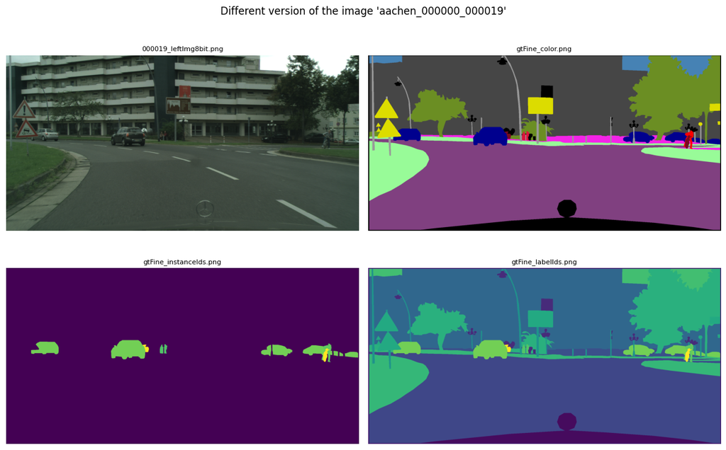

```python
# now we print all the images in one figure


# built list of all images to plot
images = [Path(sample_image['image_path'])] + [f for f in ann_files if f.suffix == '.png']

fig, axs = plt.subplots(2, 2, figsize=(12, 8))
axs = np.ravel(axs)  # flatten into 1D array

for i, f in enumerate(images):
    img = Image.open(f)
    axs[i].imshow(np.array(img))
    axs[i].set_title('_'.join(f.name.split('_')[-2:]), fontsize=8)
    axs[i].axis('off')

plt.suptitle(f"Different version of the image '{sample_image['image_name']}'")
plt.tight_layout()
plt.show()
```

```python
import numpy as np
from PIL import Image

# path to instanceIds image
img_path = ann_files[1]

# load image
instance_img = np.array(Image.open(img_path))

CLASS_ID = 26
CLASS_BASE = CLASS_ID * 1000

# get all unique instance IDs
unique_ids = np.unique(instance_img)

# select only instances of class 26
car_instance_ids = [
    iid for iid in unique_ids
    if CLASS_BASE <= iid < CLASS_BASE + 1000
]

print("Car instance IDs:")
print(car_instance_ids)
print(f"Number of car instances: {len(car_instance_ids)}")
```

```
Car instance IDs:
[np.uint16(26003), np.uint16(26004), np.uint16(26005), np.uint16(26006), np.uint16(26007), np.uint16(26008), np.uint16(26009), np.uint16(26010)]
Number of car instances: 8
```

As one can see in the Figure above, they provided two images that appear to have a segmentation mask, one nicely colored and one just with the corresponding label ids colored differently. Since in our opinion they do not provide us any additional value, we decided to not include the paths into the `overview_df`.

## 3 Structure of the annotation JSON files

As next we explore the strcutre of the annotation JSON files with the same sample as before.

```python
# get only the json file for this image
json_file = [f for f in ann_files if f.suffix == '.json'][0]
with open(json_file, 'r') as jf:
    ann_data = json.load(jf)


print(ann_data.keys())
ann_data['objects'][:1]
```

```
dict_keys(['imgHeight', 'imgWidth', 'objects'])
```

```
[{'label': 'road',
  'polygon': [[0, 769],
   [290, 574],
   [93, 528],
   [0, 524],
   [0, 448],
   [0, 448],
   [210, 453],
   [511, 451],
   [782, 459],
   [892, 495],
   [943, 498],
   [1044, 471],
   [1490, 486],
   [1880, 519],
   [1922, 512],
   [1975, 522],
   [2047, 524],
   [2047, 570],
   [1668, 553],
   [2047, 597],
   [2047, 1023],
   [892, 1023],
   [0, 1023]]}]
```

As we can see, the annotation dictionary is structured with basic image metadata (such as width and height) and, inside the objects list, a set of dictionaries containing labels and polygon coordinates as normal pixel values. This format does not match YOLO’s expected representation for instance segmentation, which requires annotations in the form:

`class_id x1 y1 x2 y2 x3 y3 ... xn yn`

Before addressing the transformation into YOLO format, we first add the annotation JSON path to our overview_df and visualize the polygons of a sample image to ensure we interpreted the annotations correctly.

```python
def path_to_json_file(img_name, split, city, ann_dir = ann_dir):

    ann_path = ann_dir / split / city / f"{img_name}_gtFine_polygons.json"
    return ann_path

df_overview['annotation_json'] = df_overview.apply(
    lambda row: path_to_json_file(row['image_name'], row['split'], row['city'], ann_dir),
    axis=1
)

df_overview.head()
```

|  | image_name | image_path | split | city | annotation_json |
| --- | --- | --- | --- | --- | --- |
| 0 | aachen_000000_000019 | ..\data\leftImg8bit_trainvaltest\leftImg8bit\t... | train | aachen | ..\data\gtFine_trainvaltest\gtFine\train\aache... |
| 1 | aachen_000001_000019 | ..\data\leftImg8bit_trainvaltest\leftImg8bit\t... | train | aachen | ..\data\gtFine_trainvaltest\gtFine\train\aache... |
| 2 | aachen_000002_000019 | ..\data\leftImg8bit_trainvaltest\leftImg8bit\t... | train | aachen | ..\data\gtFine_trainvaltest\gtFine\train\aache... |
| 3 | aachen_000003_000019 | ..\data\leftImg8bit_trainvaltest\leftImg8bit\t... | train | aachen | ..\data\gtFine_trainvaltest\gtFine\train\aache... |
| 4 | aachen_000004_000019 | ..\data\leftImg8bit_trainvaltest\leftImg8bit\t... | train | aachen | ..\data\gtFine_trainvaltest\gtFine\train\aache... |

```
Image: aachen_000000_000019_leftImg8bit.png
City: aachen, Split: train
Total polygons: 80
```

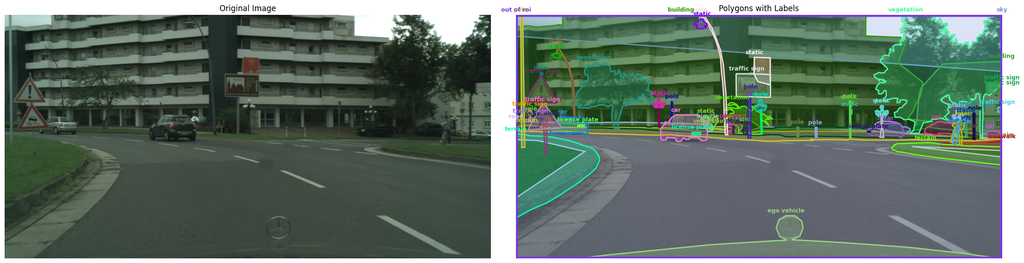

```python
import random
from matplotlib.patches import Polygon

def plot_polygons_from_df_overview(df_row, selected_classes=None, figsize=(22, 10)):
    """
    Plot the original image and on the right the same image with the polygons and labels.
    """

    # get the different paths
    img_path = Path(df_row['image_path'])
    ann_path = Path(df_row['annotation_json'])

    # Load images and annotations
    img = np.array(Image.open(img_path))
    with open(ann_path, 'r') as f:
        ann_data = json.load(f)

    objects = ann_data.get('objects', [])

    # Filter objects
    if selected_classes:
        filtered = [o for o in objects if o['label'] in selected_classes]
        title_suffix = f" (Selected: {len(selected_classes)} classes)"

        objects = [o for o in objects if o['label'] in selected_classes]
    else:
        filtered = objects
        title_suffix = ""


    print(f"Image: {img_path.name}")
    print(f"City: {df_row['city']}, Split: {df_row['split']}")
    print(f"Total polygons: {len(objects)}")
    if selected_classes:
        print(f"Shown instances: {len(filtered)}")

    fig, axs = plt.subplots(1, 2, figsize=figsize, constrained_layout=True)

    # Original image
    axs[0].imshow(img)
    axs[0].set_title("Original Image")
    axs[0].axis("off")

    # Image with polygons
    axs[1].imshow(img)
    axs[1].set_title(f"Polygons with Labels{title_suffix}")
    axs[1].axis("off")

    # Draw each polygon
    for obj in filtered:
        poly = np.array(obj["polygon"])
        label = obj["label"]
        color = (random.random(), random.random(), random.random())

        patch = Polygon(
            poly,
            closed=True,
            fill=True,
            facecolor=color + (0.25,),
            edgecolor=color,
            linewidth=2
        )
        axs[1].add_patch(patch)

        # Add label to the polygon
        highest_y_idx = np.argmin(poly[:, 1])
        x, y = poly[highest_y_idx]
        axs[1].text(
            x, y - 8, label,
            color=color,
            fontsize=9,
            fontweight="bold",
            ha="center", va="bottom",
        )

    plt.show()

plot_polygons_from_df_overview(df_overview.iloc[0], )
```

```
Image: aachen_000000_000019_leftImg8bit.png
City: aachen, Split: train
Total polygons: 11
Shown instances: 11
```

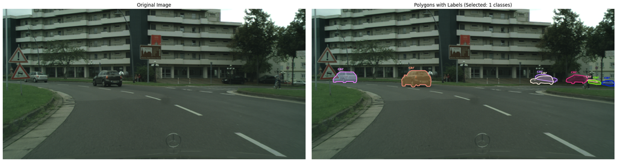

```python
plot_polygons_from_df_overview(df_overview.iloc[0], ["car"])
```

## 4 Convert the labels to YOLO format

YOLO instance segmentation expects each object as a single line

`class_id x1 y1 x2 y2 x3 y3 ... xn yn`

with all coordinates normalized to the range [0, 1]:

$$ x_{norm} = \frac{x_n}{\text{img\_width}} \qquad y_{norm} = \frac{y_n}{\text{img\_height}} $$

As shown in Section 3, the raw JSON polygons overlap neighbouring objects and are bad instance labels. We therefore build the labels from the **instanceIds rasters** instead: `InstanceImageToYOLO` (`dlbs.transform_data.instancepng_to_yolo`) extracts one polygon per connected instance via contours and normalizes them as above. The Instance Image to YOLO does the following step by step:

- **Load** the instanceIds raster (`*_gtFine_instanceIds.png`) — each pixel = `class_id · 1000 + instance_number`
- **Read** image height/width (for normalization) and the unique instance IDs
- **Per class of the available ones** (`person, rider, car, truck, bus, train, motorcycle, bicycle`):
  - select the instance IDs of that class (`class_id·1000 ≤ id < class_id·1000 + 1000`)
  - build a binary mask per instance; optionally split into connected components (`split_groups`)
  - drop masks smaller than `min_pixels`
- **Per instance mask** → take the largest external contour (OpenCV `findContours`)
- **Normalize** the contour points to [0, 1] (`x / W`, `y / H`); keep only polygons with ≥ 3 points
- **Emit** one YOLO line per instance: `class_id x1 y1 x2 y2 …`
- **Return** the lines in memory (`output_path=None`) or write them to a `.txt` (used by the SLURM batch)

The cell below is only an **example on a single file** for a visual sanity check. The conversion of *all* images runs as a batch job on the cluster via `scripts/transform_instances_to_yolo.sh` (SLURM) — see Section 5.

```python
def path_to_instance_file(img_name, split, city, ann_dir=ann_dir):
    instance_path = ann_dir / split / city / f"{img_name}_gtFine_instanceIds.png"
    return instance_path

df_overview["instance_path"] = df_overview.apply(
    lambda row: path_to_instance_file(row['image_name'], row['split'], row['city'], ann_dir),
    axis=1
)
```

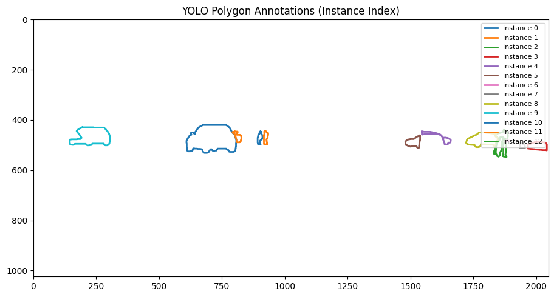

```python
from dlbs.transform_data.instancepng_to_yolo import InstanceImageToYOLO

import matplotlib.pyplot as plt

def yolo_annotation_plot(yolo_lines, img_width=2048, img_height=1024):
    """Plot YOLO segmentation polygons with a per-instance legend."""
    plt.figure(figsize=(10, 5))
    ax = plt.gca()
    ax.set_xlim(0, img_width)
    ax.set_ylim(img_height, 0)  # image coordinates
    ax.set_aspect("equal", adjustable="box")

    for idx, line in enumerate(yolo_lines):
        parts = line.split()
        coords = list(map(float, parts[1:]))
        xs = [x * img_width for x in coords[0::2]]
        ys = [y * img_height for y in coords[1::2]]
        xs.append(xs[0]); ys.append(ys[0])  # close polygon
        ax.plot(xs, ys, linewidth=2, label=f"instance {idx}")

    ax.set_title("YOLO Polygon Annotations (Instance Index)")
    ax.legend(loc="upper right", fontsize=8)
    plt.tight_layout()
    plt.show()



converter = InstanceImageToYOLO(
    split_groups=False
)

all_yolo_lines = converter.convert_single(
    input_path=df_overview["instance_path"][0],
    output_path=None
)

yolo_annotation_plot(all_yolo_lines)
```

## Build the overview table & batch conversion (via SLURM)

We now build the final `overview_df` table. For each image we compute the expected YOLO label path and save the table plus a `0_data.yaml` with the class mapping. The actual conversion of *all* 3475 images is compute-intensive and therefore does not run here, but as a batch job on the cluster:

```
sbatch scripts/transform_instances_to_yolo.sh
```

This also notes the end of the notebook, as we got an understanding of the different data annotations, and which ones we need to use for the training of the YOLO model. In the next notebook we will explore the data itself, and get an understanding of the different scenarios, and how they are distributed across the different cities.

```python
import yaml
from dlbs.transform_data.instancepng_to_yolo import InstanceImageToYOLO

YOLO_INSTANCE_DIR = Path("../data/yolo_annotations_instances")
overview_csv = Path("../data/overview_df.csv")

# 1) expected YOLO label path per image (the .txt files are written by the SLURM batch)
df_overview["instance_based_yolo"] = df_overview["instance_path"].apply(
    lambda p: str(YOLO_INSTANCE_DIR / (Path(p).stem.replace("gtFine_instanceIds", "leftImg8bit") + ".txt"))
)

# 2) class mapping for the YOLO yaml (the 8 classes the converter emits: {0: 'person', ...})
class_map = InstanceImageToYOLO().class_map

# 3) default: just load the existing table. Set GENERATE=True to (re)write csv + yaml.
GENERATE = False
if GENERATE or not overview_csv.exists():
    df_overview.to_csv(overview_csv, index=False)
    Path("../data/yolo_annotations").mkdir(parents=True, exist_ok=True)
    with open("../data/yolo_annotations/0_data.yaml", "w") as f:
        yaml.dump({"nc": len(class_map), "names": class_map}, f, sort_keys=False)
    print("Generated overview_df.csv + 0_data.yaml")
else:
    df_overview = pd.read_csv(overview_csv)
    print("Loaded existing overview_df.csv (set GENERATE=True to rebuild)")

df_overview.head()
```

```
Loaded existing overview_df.csv (set GENERATE=True to rebuild)
```

|  | image_name | image_path | split | city | annotation_json | instance_path | yolo_annotation_path | instance_based_yolo |
| --- | --- | --- | --- | --- | --- | --- | --- | --- |
| 0 | aachen_000000_000019 | ..\data\leftImg8bit_trainvaltest\leftImg8bit\t... | train | aachen | ..\data\gtFine_trainvaltest\gtFine\train\aache... | ..\data\gtFine_trainvaltest\gtFine\train\aache... | ..\data\yolo_annotations\aachen_000000_000019_... | ..\data\yolo_annotations_instances\aachen_0000... |
| 1 | aachen_000001_000019 | ..\data\leftImg8bit_trainvaltest\leftImg8bit\t... | train | aachen | ..\data\gtFine_trainvaltest\gtFine\train\aache... | ..\data\gtFine_trainvaltest\gtFine\train\aache... | ..\data\yolo_annotations\aachen_000001_000019_... | ..\data\yolo_annotations_instances\aachen_0000... |
| 2 | aachen_000002_000019 | ..\data\leftImg8bit_trainvaltest\leftImg8bit\t... | train | aachen | ..\data\gtFine_trainvaltest\gtFine\train\aache... | ..\data\gtFine_trainvaltest\gtFine\train\aache... | ..\data\yolo_annotations\aachen_000002_000019_... | ..\data\yolo_annotations_instances\aachen_0000... |
| 3 | aachen_000003_000019 | ..\data\leftImg8bit_trainvaltest\leftImg8bit\t... | train | aachen | ..\data\gtFine_trainvaltest\gtFine\train\aache... | ..\data\gtFine_trainvaltest\gtFine\train\aache... | ..\data\yolo_annotations\aachen_000003_000019_... | ..\data\yolo_annotations_instances\aachen_0000... |
| 4 | aachen_000004_000019 | ..\data\leftImg8bit_trainvaltest\leftImg8bit\t... | train | aachen | ..\data\gtFine_trainvaltest\gtFine\train\aache... | ..\data\gtFine_trainvaltest\gtFine\train\aache... | ..\data\yolo_annotations\aachen_000004_000019_... | ..\data\yolo_annotations_instances\aachen_0000... |